# PS5-rmarkdown

Tianshi Xu

2023-02-15

#1 Load and check data (5pt)

You first task is to do a very simple data check:

1. (1pt) For solving the problems, and answering the questions, create a new rmarkdown document with an appropriate title. See https://faculty.washington.edu/otoomet/info201-book/r-markdown.html#r-markdown-rstudio-creating.

#Obviously, this rmarkdown was successfully created.

2. (2pt) Load data. How many rows/columns do we have?

```r
library(tidyverse)
gapminder <- read_delim("gapminder.csv.bz2")
dim(gapminder)
```

```
## [1] 13055    25
```

3. (2pt) Print a small sample of data. Does it look OK?

```r
gapminder %>%
  sample_n(10)
```

```
## # A tibble: 10 × 25
##    iso3  name         iso2  region sub-r…¹ inter…²  time total…³ ferti…⁴ lifeE…⁵
##    <chr> <chr>        <chr> <chr>  <chr>   <chr>   <dbl>   <dbl>   <dbl>   <dbl>
##  1 KNA   Saint Kitts… KN    Ameri… Latin … Caribb…  1976  4.41e4   NA       NA
##  2 RWA   Rwanda       RW    Africa Sub-Sa… Easter…  1967  3.42e6    8.20    44.4
##  3 PHL   Philippines  PH    Asia   South-… <NA>     1981  4.87e7    5.08    63.9
##  4 TCD   Chad         TD    Africa Sub-Sa… Middle…  2018  1.55e7    5.75    54.0
##  5 FRO   Faroe Islan… FO    Europe Northe… <NA>     1988  4.68e4    2.6     75.7
##  6 PNG   Papua New G… PG    Ocean… Melane… <NA>     1971  2.85e6    6.14    46.7
##  7 NAM   Namibia      <NA>  Africa Sub-Sa… Southe…  1972  8.69e5    6.56    53.7
##  8 COD   Congo, Demo… CD    Africa Sub-Sa… Middle…  1984  2.91e7    6.64    47.5
##  9 HKG   Hong Kong    HK    Asia   Easter… <NA>     2014  7.23e6    1.24    84.0
## 10 AUT   Austria      AT    Europe Wester… <NA>     2019  8.88e6    1.46    81.8
## # … with 15 more variables: childMortality <dbl>, youthFemaleLiteracy <dbl>,
## #   youthMaleLiteracy <dbl>, adultLiteracy <dbl>, GDP_PC <dbl>,
## #   accessElectricity <dbl>, agriculturalLand <dbl>, agricultureTractors <dbl>,
## #   cerealProduction <dbl>, fertilizerHa <dbl>, co2 <dbl>,
## #   greenhouseGases <dbl>, co2_PC <dbl>, pm2.5_35 <dbl>, battleDeaths <dbl>,
## #   and abbreviated variable names ¹`sub-region`, ²`intermediate-region`,
## #   ³totalPopulation, ⁴fertilityRate, ⁵lifeExpectancy
```

#2 Descriptive statistics (15pt)

1. (3pt) How many countries are there in the dataset? Analyze all three: iso3, iso2 and name.

There are 250 countries in total. 253 countries have 3-letter country code. 249 countries have 2-letter country code.

2. If you did this correctly, you saw that there are more names than iso-2 codes, and there are even more iso3 -codes. What is going on? Can you find it out?
1. (5pt) Find how many names are there for each iso-2 code. Are there any iso-2 codes that correspond to more than one name? What are these countries?

```r
iso2_code <- gapminder %>%
  group_by(iso2) %>%
  summarise(n_names = n_distinct(name))

head(iso2_code)
```

```
## # A tibble: 6 × 2
##   iso2  n_names
##   <chr>   <int>
## 1 AD          1
## 2 AE          1
## 3 AF          1
## 4 AG          1
## 5 AI          1
## 6 AL          1
```

```r
iso2_multiple_names <- iso2_code %>%
  filter(n_names > 1) %>%
  inner_join(gapminder, by = "iso2") %>%
  select(name, iso2) %>%
  distinct()
iso2_multiple_names
```

```
## # A tibble: 2 × 2
##   name    iso2
##   <chr>   <chr>
## 1 <NA>    <NA>
## 2 Namibia <NA>
```

2. (5pt) Now repeat the same for name and iso3-code. Are there country names that have more than one iso3-code? What are these countries? Hint: two of these entitites are CHANISL and NLD CURACAO.

```r
iso3_code <- gapminder %>%
  group_by(name) %>%
  summarize(num_iso3 = n_distinct(iso3)) %>%
  filter(num_iso3 > 1) %>%
  arrange(desc(num_iso3))
iso3_code
```

```
## # A tibble: 1 × 2
##   name  num_iso3
##   <chr>    <int>
## 1 <NA>         4
```

3. (2pt) What is the minimum and maximum year in these data?

The minimum year is 1960, the maximum year is 2019.

#3 CO2 emissions (30pt)

Next, let’s analyze CO2 emissions.

1. (2pt) How many missing co2 emissions are there for each year? Analyze both missing CO2 and co2_PC. Which years have most missing data?

There are 2658 missing co2 data, 2661 missing co2_PC data.

```r
gapminder %>%
  group_by(time) %>%
  summarize(missing_co2 = sum(is.na(co2)))
```

```
## # A tibble: 61 × 2
##     time missing_co2
##    <dbl>       <int>
##  1  1960          60
##  2  1961          60
##  3  1962          58
##  4  1963          57
##  5  1964          51
##  6  1965          51
##  7  1966          51
##  8  1967          51
##  9  1968          51
## 10  1969          51
## # … with 51 more rows
```

```r
gapminder %>%
  group_by(time) %>%
  summarize(missing_co2_PC = sum(is.na(co2_PC)))
```

```
## # A tibble: 61 × 2
##     time missing_co2_PC
##    <dbl>          <int>
##  1  1960             60
##  2  1961             60
##  3  1962             58
##  4  1963             57
##  5  1964             51
##  6  1965             51
##  7  1966             51
##  8  1967             51
##  9  1968             51
## 10  1969             51
## # … with 51 more rows
```

```r
gapminder %>%
  group_by(time) %>%
  summarize(missing_co2 = sum(is.na(co2))) %>%
  arrange(desc(missing_co2)) %>%
  head(1)
```

```
## # A tibble: 1 × 2
##    time missing_co2
##   <dbl>       <int>
## 1  2017         217
```

```r
gapminder %>%
  group_by(time) %>%
  summarize(missing_co2_PC = sum(is.na(co2_PC))) %>%
  arrange(desc(missing_co2_PC)) %>%
  head(1)
```

```
## # A tibble: 1 × 2
##    time missing_co2_PC
##   <dbl>          <int>
## 1  2017            217
```

2. (5pt) Make a plot of total CO2 emissions over time for the U.S, China, and India. Add a few more countries of your choice. Explain what do you see.

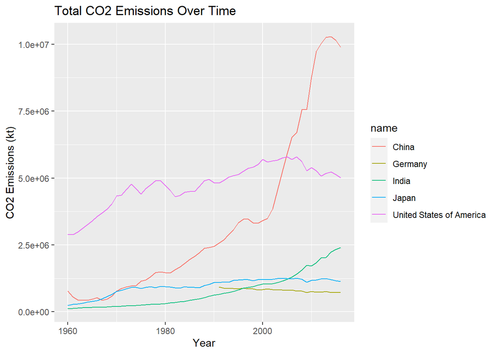

```r
co2_data <- gapminder %>%
  filter(!is.na(co2)) %>%
  select(name, time, co2)

countries_of_interest <- c("United States of America", "China", "India", "Germany", "Japan")

co2_data_selected_countries <- co2_data %>%
  filter(name %in% countries_of_interest)

ggplot(co2_data_selected_countries, aes(x = time, y = co2, color = name)) +
  geom_line() +
  labs(title = "Total CO2 Emissions Over Time",
       x = "Year",
       y = "CO2 Emissions (kt)")
```